# Spatial databases and SQL

GEOG 40323

January 30, 2018

## Flat files

- Rows of information stored as text or binary files
- Examples: comma-delimited (CSV) files, spreadsheets

## Databases and DBMS

- **Database**: an organized collection of data
- **Database Management System (DBMS)**: computer program that allows you to store and manipulate your data
- Example DBMS: PostgreSQL/PostGIS

## The relational model

- Tables (representation of *relations*) can be associated with one another based on common fields

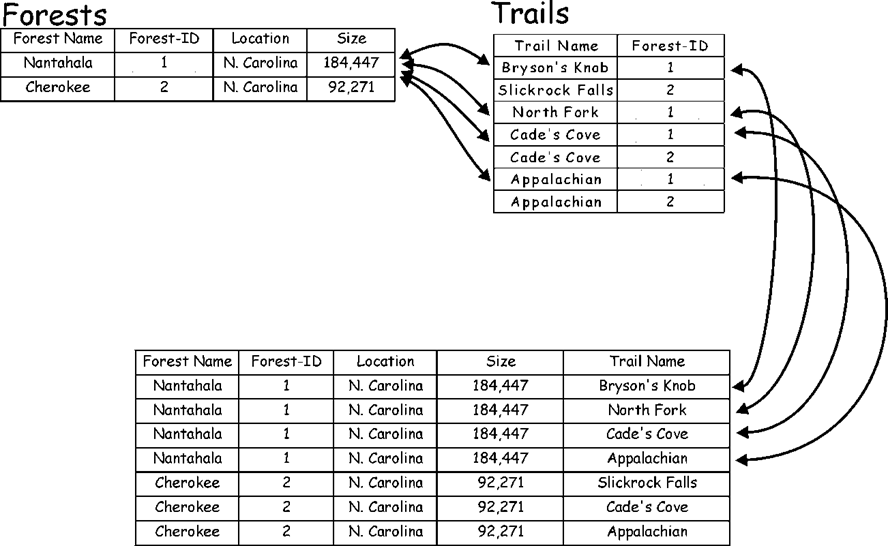

## Structure of a database

- **Schema**: structural description of relations (tables) in a database
- **Instance**: specific contents at a given point in time
- **Key**: attribute whose value is unique for each record (or which can be combined with another attribute to make a unique value)
- Used to establish relationships between tables

### Structure of a database (GIS)

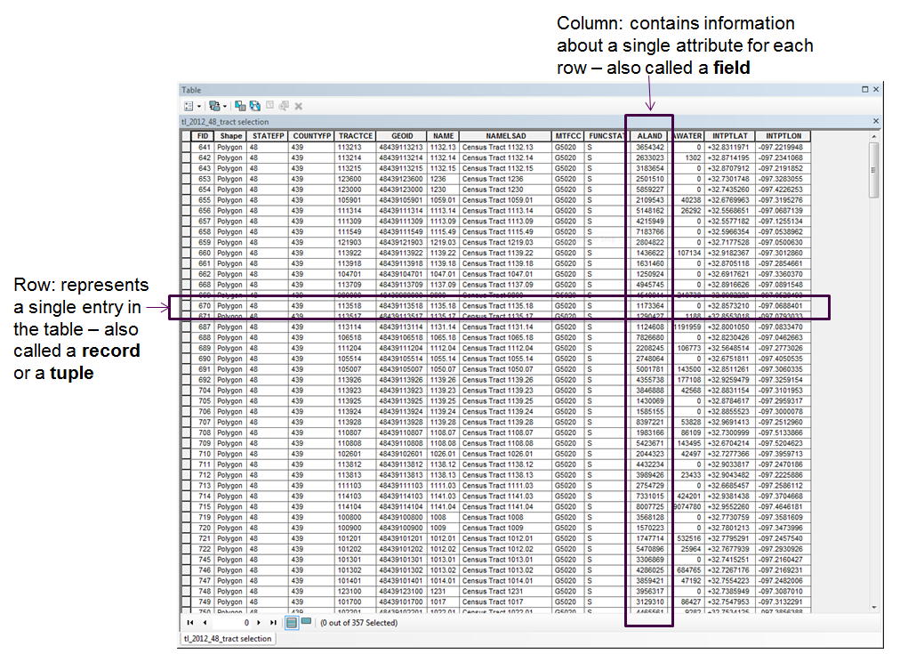

## CARTO

- Web-based platform for data management and visualization; uses PostGIS as a backend
- Free trials available and free accounts for students: https://carto.com/get-started/

### Today’s data

- Our data for today: traffic accidents in Fort Worth over the past month
- Data available on TCU Online

### Brief tour of CARTO

- Adding data to CARTO
- Styling point data

### Review: levels of measurement

Explain the following levels of measurement:

- Nominal
- Ordinal
- Interval
- Ratio

### Review: Column types

- Numeric
- Integers (short or long)
- Floating-point numbers (float or double)
- Text (string)
- Boolean (true/false)
- Dates

## Structured Query Language (SQL)

- Standard syntax for querying & working with databases; available in the SQL pane in CartoDB

Example statement:

```sql
SELECT * FROM accidents
    WHERE hit_and_run = true
```

## Basic SQL statements

- `CREATE TABLE`: used to create a table in the database. Parameters must be defined with this statement.
- `SELECT`: used to subset databases. Can be used in concert with:
- `FROM`: defines the table used to create the subset
- `WHERE`: specifies conditions that will define the subset

## Basic SQL statements

- `GROUP BY`: specifies how to display the result (aggregation function); used with `SUM`, `MAX`, `MIN`, `AVG`, `COUNT`, etc.
- `JOIN`: used to establish relationships between tables in a database
- `UPDATE`, `INSERT`, `DELETE`: used to modify rows in a database table
- `ORDER BY`: sort values in a table (`DESC` for descending order)

## Example

```sql
SELECT street_name, COUNT(cartodb_id) as street_count
    FROM accidents
    GROUP BY street_name
    ORDER BY street_count DESC
```

### Dates in CARTO

- Temporal animations are available in CartoDB if an appropriate date column is set; in our dataset, this is `crash_date_time`
- To convert columns in CARTO: click the column heading, then choose “Change data type…”

### Dates and SQL

```sql
SELECT COUNT(cartodb_id) AS count,
       DATE_PART('hour', crash_date_time) AS hour
  FROM accidents
  GROUP BY hour
  ORDER BY count DESC
```

## Spatial databases

- Key distinction: a spatial database contains a column that stores the **geometry** of the records in the database
- In CARTO, this is column is called `the_geom`
- Analogous to the “Shape” field in ArcGIS
- `the_geom_webmercator`: feature geometry in projected coordinates, with the meter as the unit of measurement

## Spatial SQL

- Extends SQL to perform GIS operations on spatial data in the database
- CARTO: a full-fledged spatial database with spatial SQL available

### Example: buffering points

```sql
SELECT
  cartodb_id, ST_Buffer(the_geom_webmercator, 500) as the_geom_webmercator
    FROM accidents
```

## GIS functionality in CARTO

- CARTO includes functionality for several common GIS operations with its ANALYSIS options
- Example: what are the nearest accidents to TCU?